# Estudis d'Informàtica, Multimedia i Telecomunicacions

# Mineria de dades: PAC3 - Classificació amb arbres de decisió

Autor: Arnau Garcia Rodríguez

Desembre 2023

# 1 Joc de dades

Utilitzarem el joc de dades ‘*Credit approval*’, obtingut a https://www.kaggle.com/shravan3273/credit-approval. Aquest conté informació sobre clients i indica si han complert o no les obligacions dels préstecs anteriors. Aquesta última dada ens servirà per dur a terme un projecte de mineria de dades sobre **algoritmes supervisats**, més concretament d’**arbres de decisió**, on generarem un joc de dades d’entrenament i un de proves per generar un model de predicció.

El primer pas es carregar el joc de dades:

```r
data<-read.csv("./credit.csv",header=T,sep=",")
attach(data)
```

## 1.1 Descripció dels atributs

- checking_balance: Estat del compte corrent existent. Categòrica.
- months_loan_duration: Duració del prèstec en mesos. Contínua.
- credit_history: Historial de crèdits. Categòrica.
- purpose: Motiu del crèdit. Categòrica.
- amount: Quantitat. Contínua.
- savings_balance: Quantitat estlaviada. Categòrica.
- employment_length: Duració a la feina actual. Categòrica.
- installment_rate: Taxa de pagament a terminis en porcentaje respecte l’ingrés disponible. Contínua.
- personal_status: Estat civil i sexe. Categòrica.
- other_debtors: Altres deutors. Categòrica.
- residence_history: Duració a la seva residència actual. Contínua.
- property: Tipus de propietat. Categòrica.
- age: Edat en anys. Contínua.
- installment_plan: Altres plans de fraccionament. Categòrica.
- housing: Habitatge. Categòrica.
- existing_credits: Crèdits existens en aquest banc. Contínua.
- default: Client va cumplir o inclumplir prèstecs anteriors. Binària.
- dependents: Nombre de persones dependents. Contínua.
- telephone: Número de telèfon. Binària.
- foreign_worker: Treballador estranger. Binària.
- job: Feina. Categòrica.

# 2 Anàlisi inicial

Donarem un primer cop d’ull a les dades, observant-ne les dimensions i quin tipus d’atributs tenim.

```r
dim(data)
```

```
## [1] 1000   21
```

Com podem observar, disposem de **1000 tuples** i **21 atributs**. A continuació, descriurem cadascun d’aquests.

```r
str(data)
```

```
## 'data.frame':    1000 obs. of  21 variables:
##  $ checking_balance    : chr  "< 0 DM" "1 - 200 DM" "unknown" "< 0 DM" ...
##  $ months_loan_duration: int  6 48 12 42 24 36 24 36 12 30 ...
##  $ credit_history      : chr  "critical" "repaid" "critical" "repaid" ...
##  $ purpose             : chr  "radio/tv" "radio/tv" "education" "furniture" ...
##  $ amount              : int  1169 5951 2096 7882 4870 9055 2835 6948 3059 5234 ...
##  $ savings_balance     : chr  "unknown" "< 100 DM" "< 100 DM" "< 100 DM" ...
##  $ employment_length   : chr  "> 7 yrs" "1 - 4 yrs" "4 - 7 yrs" "4 - 7 yrs" ...
##  $ installment_rate    : int  4 2 2 2 3 2 3 2 2 4 ...
##  $ personal_status     : chr  "single male" "female" "single male" "single male" ...
##  $ other_debtors       : chr  "none" "none" "none" "guarantor" ...
##  $ residence_history   : int  4 2 3 4 4 4 4 2 4 2 ...
##  $ property            : chr  "real estate" "real estate" "real estate" "building society savings" ...
##  $ age                 : int  67 22 49 45 53 35 53 35 61 28 ...
##  $ installment_plan    : chr  "none" "none" "none" "none" ...
##  $ housing             : chr  "own" "own" "own" "for free" ...
##  $ existing_credits    : int  2 1 1 1 2 1 1 1 1 2 ...
##  $ default             : int  1 2 1 1 2 1 1 1 1 2 ...
##  $ dependents          : int  1 1 2 2 2 2 1 1 1 1 ...
##  $ telephone           : chr  "yes" "none" "none" "none" ...
##  $ foreign_worker      : chr  "yes" "yes" "yes" "yes" ...
##  $ job                 : chr  "skilled employee" "skilled employee" "unskilled resident" "skilled employee" ...
```

```r
summary(data)
```

```
##  checking_balance   months_loan_duration credit_history       purpose
##  Length:1000        Min.   : 4.0         Length:1000        Length:1000
##  Class :character   1st Qu.:12.0         Class :character   Class :character
##  Mode  :character   Median :18.0         Mode  :character   Mode  :character
##                     Mean   :20.9
##                     3rd Qu.:24.0
##                     Max.   :72.0
##      amount      savings_balance    employment_length  installment_rate
##  Min.   :  250   Length:1000        Length:1000        Min.   :1.000
##  1st Qu.: 1366   Class :character   Class :character   1st Qu.:2.000
##  Median : 2320   Mode  :character   Mode  :character   Median :3.000
##  Mean   : 3271                                         Mean   :2.973
##  3rd Qu.: 3972                                         3rd Qu.:4.000
##  Max.   :18424                                         Max.   :4.000
##  personal_status    other_debtors      residence_history   property
##  Length:1000        Length:1000        Min.   :1.000     Length:1000
##  Class :character   Class :character   1st Qu.:2.000     Class :character
##  Mode  :character   Mode  :character   Median :3.000     Mode  :character
##                                        Mean   :2.845
##                                        3rd Qu.:4.000
##                                        Max.   :4.000
##       age        installment_plan     housing          existing_credits
##  Min.   :19.00   Length:1000        Length:1000        Min.   :1.000
##  1st Qu.:27.00   Class :character   Class :character   1st Qu.:1.000
##  Median :33.00   Mode  :character   Mode  :character   Median :1.000
##  Mean   :35.55                                         Mean   :1.407
##  3rd Qu.:42.00                                         3rd Qu.:2.000
##  Max.   :75.00                                         Max.   :4.000
##     default      dependents     telephone         foreign_worker
##  Min.   :1.0   Min.   :1.000   Length:1000        Length:1000
##  1st Qu.:1.0   1st Qu.:1.000   Class :character   Class :character
##  Median :1.0   Median :1.000   Mode  :character   Mode  :character
##  Mean   :1.3   Mean   :1.155
##  3rd Qu.:2.0   3rd Qu.:1.000
##  Max.   :2.0   Max.   :2.000
##      job
##  Length:1000
##  Class :character
##  Mode  :character
##
##
##
```

Transformem les variables a tipus factor per veure quants valors existeixen per variable.

```r
data[] <- lapply(data, factor)
str(data)
```

```
## 'data.frame':    1000 obs. of  21 variables:
##  $ checking_balance    : Factor w/ 4 levels "< 0 DM","> 200 DM",..: 1 3 4 1 1 4 4 3 4 3 ...
##  $ months_loan_duration: Factor w/ 33 levels "4","5","6","7",..: 3 30 9 27 18 24 18 24 9 22 ...
##  $ credit_history      : Factor w/ 5 levels "critical","delayed",..: 1 5 1 5 2 5 5 5 5 1 ...
##  $ purpose             : Factor w/ 10 levels "business","car (new)",..: 8 8 5 6 2 5 6 3 8 2 ...
##  $ amount              : Factor w/ 921 levels "250","276","338",..: 143 771 391 849 735 870 534 814 563 748 ...
##  $ savings_balance     : Factor w/ 5 levels "< 100 DM","> 1000 DM",..: 5 1 1 1 1 5 4 1 2 1 ...
##  $ employment_length   : Factor w/ 5 levels "> 7 yrs","0 - 1 yrs",..: 1 3 4 4 3 3 1 3 4 5 ...
##  $ installment_rate    : Factor w/ 4 levels "1","2","3","4": 4 2 2 2 3 2 3 2 2 4 ...
##  $ personal_status     : Factor w/ 4 levels "divorced male",..: 4 2 4 4 4 4 4 4 1 3 ...
##  $ other_debtors       : Factor w/ 3 levels "co-applicant",..: 3 3 3 2 3 3 3 3 3 3 ...
##  $ residence_history   : Factor w/ 4 levels "1","2","3","4": 4 2 3 4 4 4 4 2 4 2 ...
##  $ property            : Factor w/ 4 levels "building society savings",..: 3 3 3 1 4 4 1 2 3 2 ...
##  $ age                 : Factor w/ 53 levels "19","20","21",..: 49 4 31 27 35 17 35 17 43 10 ...
##  $ installment_plan    : Factor w/ 3 levels "bank","none",..: 2 2 2 2 2 2 2 2 2 2 ...
##  $ housing             : Factor w/ 3 levels "for free","own",..: 2 2 2 1 1 1 2 3 2 2 ...
##  $ existing_credits    : Factor w/ 4 levels "1","2","3","4": 2 1 1 1 2 1 1 1 1 2 ...
##  $ default             : Factor w/ 2 levels "1","2": 1 2 1 1 2 1 1 1 1 2 ...
##  $ dependents          : Factor w/ 2 levels "1","2": 1 1 2 2 2 2 1 1 1 1 ...
##  $ telephone           : Factor w/ 2 levels "none","yes": 2 1 1 1 1 2 1 2 1 1 ...
##  $ foreign_worker      : Factor w/ 2 levels "no","yes": 2 2 2 2 2 2 2 2 2 2 ...
##  $ job                 : Factor w/ 4 levels "mangement self-employed",..: 2 2 4 2 2 4 2 1 4 1 ...
```

Veiem com per a les variables contínues el resultat és més elevat, com era d’esperar. L’exemple més clar és la variable **amount**, amb 921 *levels*.

A continuació executarem la funció *summary* per veure la distribució de valors per variable i per trobar possibles valors nuls.

```r
summary(data)
```

```
##    checking_balance months_loan_duration                credit_history
##  < 0 DM    :274     24     :184          critical              :293
##  > 200 DM  : 63     12     :179          delayed               : 88
##  1 - 200 DM:269     18     :113          fully repaid          : 40
##  unknown   :394     36     : 83          fully repaid this bank: 49
##                     6      : 75          repaid                :530
##                     15     : 64
##                     (Other):302
##        purpose        amount         savings_balance  employment_length
##  radio/tv  :280   1258   :  3   < 100 DM     :603    > 7 yrs   :253
##  car (new) :234   1262   :  3   > 1000 DM    : 48    0 - 1 yrs :172
##  furniture :181   1275   :  3   101 - 500 DM :103    1 - 4 yrs :339
##  car (used):103   1393   :  3   501 - 1000 DM: 63    4 - 7 yrs :174
##  business  : 97   1478   :  3   unknown      :183    unemployed: 62
##  education : 50   433    :  2
##  (Other)   : 55   (Other):983
##  installment_rate      personal_status      other_debtors residence_history
##  1:136            divorced male: 50    co-applicant: 41   1:130
##  2:231            female       :310    guarantor   : 52   2:308
##  3:157            married male : 92    none        :907   3:149
##  4:476            single male  :548                       4:413
##
##
##
##                      property        age      installment_plan     housing
##  building society savings:232   27     : 51   bank  :139       for free:108
##  other                   :332   26     : 50   none  :814       own     :713
##  real estate             :282   23     : 48   stores: 47       rent    :179
##  unknown/none            :154   24     : 44
##                                 28     : 43
##                                 25     : 41
##                                 (Other):723
##  existing_credits default dependents telephone  foreign_worker
##  1:633            1:700   1:845      none:596   no : 37
##  2:333            2:300   2:155      yes :404   yes:963
##  3: 28
##  4:  6
##
##
##
##                       job
##  mangement self-employed:148
##  skilled employee       :630
##  unemployed non-resident: 22
##  unskilled resident     :200
##
##
##
```

Podem veure com existeixen 700 clients que han complert amb préstecs anteriors i 300 que no ho han fet. És a dir, el **70%** no són clients de risc.

Sembla que no hi ha valors nuls, tot i que tenim valors desconeguts marcats com *unknown* a les variables **checking_balance**, **savings_balance** i **property**. Ara, busquem valors no disponibles (NA).

```r
missing <- data[is.na(data),]
dim(missing)
```

```
## [1]  0 21
```

L’execució mostra que no hi ha valors NA.

Les dades es troben bastant preparades per a l’anàlisi de dades, per la qual cosa ens facilitarà la feina i ens estalviarà passos a la fase de Preprocessament de les dades.

Per tant, tenim dades sense valors nuls i 21 variables.

## 2.1 Visualització de les dades

Instal·larem llibreries per utilitzar diferents eines de visualització per a les nostres dades.

```r
if(!require(ggplot2)){
    install.packages('ggplot2', repos='http://cran.us.r-project.org')
    library(ggplot2)
}
if(!require(ggpubr)){
    install.packages('ggpubr', repos='http://cran.us.r-project.org')
    library(ggpubr)
}
if(!require(grid)){
    install.packages('grid', repos='http://cran.us.r-project.org')
    library(grid)
}
if(!require(gridExtra)){
    install.packages('gridExtra', repos='http://cran.us.r-project.org')
    library(gridExtra)
}
if(!require(C50)){
    install.packages('C50', repos='http://cran.us.r-project.org')
    library(C50)
}
```

Les variables del joc de dades amb les que treballarem seran:

- employment_length
- checking_balance
- personal_status
- credit_history
- savings_balance
- purpose
- default

A continuació, analitzarem les dades mitjançant gràfics de columnes.

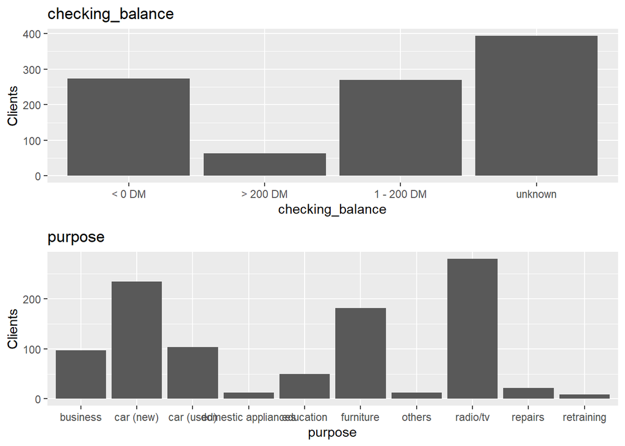

```r
grid.newpage()
plotbyCheckingBalance<-ggplot(data,aes(checking_balance))+geom_bar() +labs(x="checking_balance", y="Clients")+ guides(fill=guide_legend(title=""))+
scale_fill_manual(values=c("blue","#008000"))+ggtitle("checking_balance")
plotbyPurpose<-ggplot(data,aes(purpose))+geom_bar() +labs(x="purpose", y="Clients")+ guides(fill=guide_legend(title=""))+
scale_fill_manual(values=c("blue","#008000"))+ggtitle("purpose")
grid.arrange(plotbyCheckingBalance,plotbyPurpose,ncol=1)
```

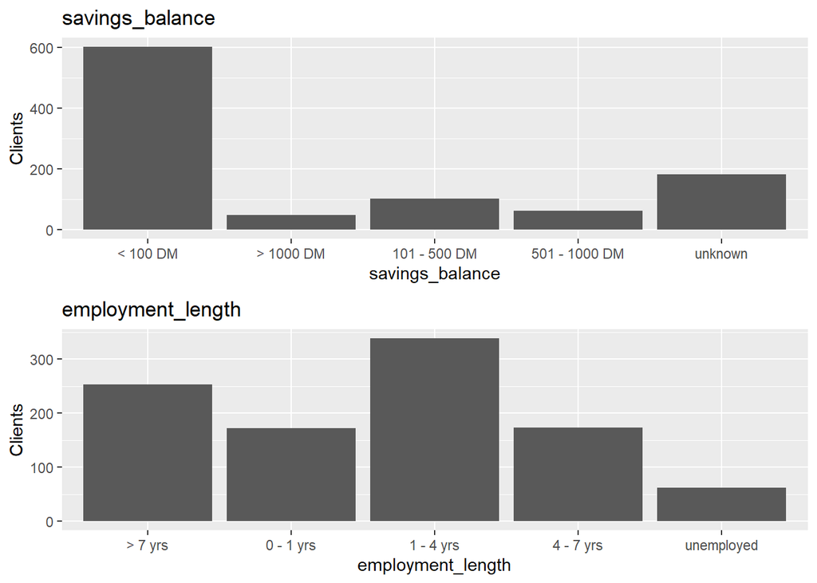

```r
grid.newpage()

plotbySavings<-ggplot(data,aes(savings_balance))+geom_bar() +labs(x="savings_balance", y="Clients")+ guides(fill=guide_legend(title=""))+
scale_fill_manual(values=c("blue","#008000"))+ggtitle("savings_balance")
plotbyEmploymentLength<-ggplot(data,aes(employment_length))+geom_bar() +labs(x="employment_length", y="Clients")+ guides(fill=guide_legend(title=""))+
scale_fill_manual(values=c("blue","#008000"))+ggtitle("employment_length")

grid.arrange(plotbySavings,plotbyEmploymentLength,ncol=1)
```

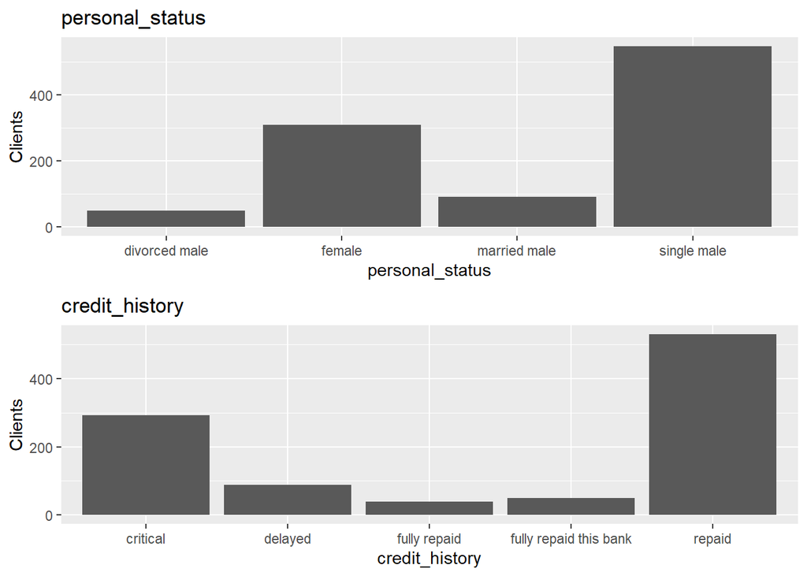

```r
grid.newpage()
plotbyPersonalStatus<-ggplot(data,aes(personal_status))+geom_bar() +labs(x="personal_status", y="Clients")+ guides(fill=guide_legend(title=""))+
scale_fill_manual(values=c("blue","#008000"))+ggtitle("personal_status")
plotbyCreditHistory<-ggplot(data,aes(credit_history))+geom_bar() +labs(x="credit_history", y="Clients")+ guides(fill=guide_legend(title=""))+
scale_fill_manual(values=c("blue","#008000"))+ggtitle("credit_history")
grid.arrange(plotbyPersonalStatus,plotbyCreditHistory,ncol=1)
```

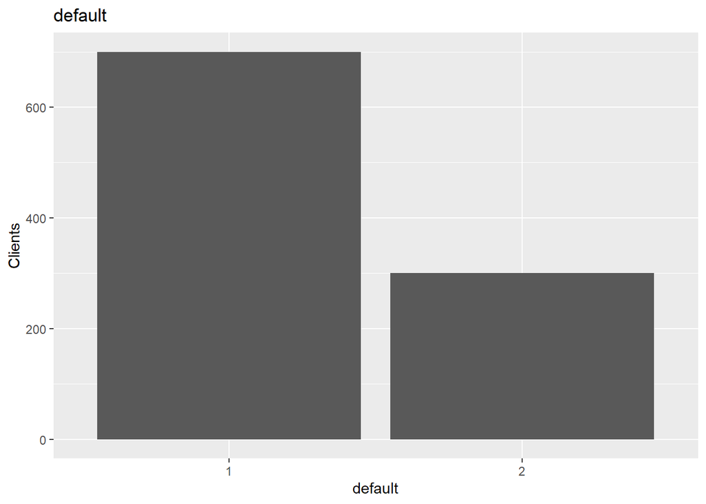

```r
grid.newpage()
plotbyDefault<-ggplot(data,aes(default))+geom_bar() +labs(x="default", y="Clients")+ guides(fill=guide_legend(title=""))+
scale_fill_manual(values=c("blue","#008000"))+ggtitle("default")
grid.arrange(plotbyDefault,ncol=1)
```

Les observacions coincideixen amb les extretes del resultat de l’execució de summary()

Descriurem la relació entre clients de risc i una selecció de les variables mitjançant gràfics de barres i taules de contingència.

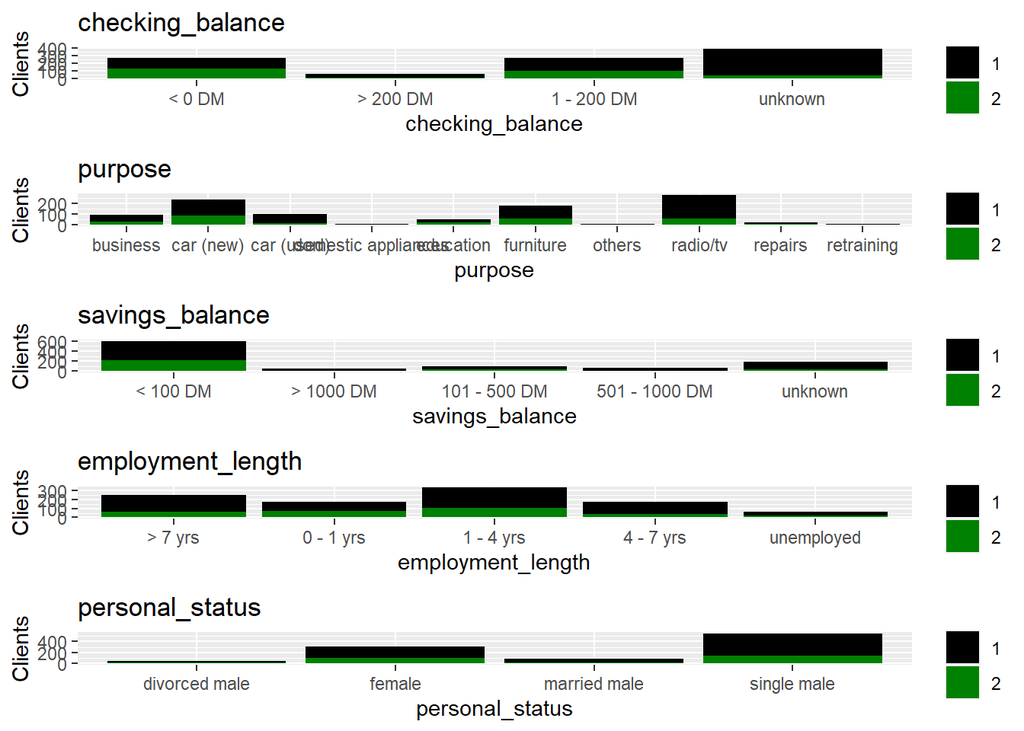

```r
grid.newpage()
plotbyCheckingBalance<-ggplot(data,aes(checking_balance,fill=default))+geom_bar() +labs(x="checking_balance", y="Clients")+ guides(fill=guide_legend(title=""))+ scale_fill_manual(values=c("black","#008000"))+ggtitle("checking_balance")
plotbyPurpose<-ggplot(data,aes(purpose,fill=default))+geom_bar() +labs(x="purpose", y="Clients")+ guides(fill=guide_legend(title=""))+ scale_fill_manual(values=c("black","#008000"))+ggtitle("purpose")
plotbySavings<-ggplot(data,aes(savings_balance,fill=default))+geom_bar() +labs(x="savings_balance", y="Clients")+ guides(fill=guide_legend(title=""))+ scale_fill_manual(values=c("black","#008000"))+ggtitle("savings_balance")
plotbyEmplLength<-ggplot(data,aes(employment_length,fill=default))+geom_bar() +labs(x="employment_length", y="Clients")+ guides(fill=guide_legend(title=""))+ scale_fill_manual(values=c("black","#008000"))+ggtitle("employment_length")
plotbyPersonalStatus<-ggplot(data,aes(personal_status,fill=default))+geom_bar() +labs(x="personal_status", y="Clients")+ guides(fill=guide_legend(title=""))+ scale_fill_manual(values=c("black","#008000"))+ggtitle("personal_status")
grid.arrange(plotbyCheckingBalance,plotbyPurpose,plotbySavings,plotbyEmplLength,plotbyPersonalStatus,ncol=1)
```

A continuació, mostrarem taules de contingències per completar la representació gràfica de les relacions entre les variables anteriors.

```r
tabla_CS <- table(checking_balance, savings_balance)
tabla_CS
```

```
##                 savings_balance
## checking_balance < 100 DM > 1000 DM 101 - 500 DM 501 - 1000 DM unknown
##       < 0 DM          219         6           12             8      29
##       > 200 DM         41         3            5             4      10
##       1 - 200 DM      152        14           47            11      45
##       unknown         191        25           39            40      99
```

```r
prop.table(tabla_CS, margin = 1)
```

```
##                 savings_balance
## checking_balance   < 100 DM  > 1000 DM 101 - 500 DM 501 - 1000 DM    unknown
##       < 0 DM     0.79927007 0.02189781   0.04379562    0.02919708 0.10583942
##       > 200 DM   0.65079365 0.04761905   0.07936508    0.06349206 0.15873016
##       1 - 200 DM 0.56505576 0.05204461   0.17472119    0.04089219 0.16728625
##       unknown    0.48477157 0.06345178   0.09898477    0.10152284 0.25126904
```

```r
tabla_SP <- table(personal_status,purpose)
tabla_SP
```

```
##                purpose
## personal_status business car (new) car (used) domestic appliances education
##   divorced male       10        10          3                   1         1
##   female              19        70         24                   6        21
##   married male         9        20          6                   1         1
##   single male         59       134         70                   4        27
##                purpose
## personal_status furniture others radio/tv repairs retraining
##   divorced male        15      1        7       2          0
##   female               74      3       85       5          3
##   married male          7      0       42       3          3
##   single male          85      8      146      12          3
```

```r
prop.table(tabla_SP, margin = 1)
```

```
##                purpose
## personal_status    business   car (new)  car (used) domestic appliances
##   divorced male 0.200000000 0.200000000 0.060000000         0.020000000
##   female        0.061290323 0.225806452 0.077419355         0.019354839
##   married male  0.097826087 0.217391304 0.065217391         0.010869565
##   single male   0.107664234 0.244525547 0.127737226         0.007299270
##                purpose
## personal_status   education   furniture      others    radio/tv     repairs
##   divorced male 0.020000000 0.300000000 0.020000000 0.140000000 0.040000000
##   female        0.067741935 0.238709677 0.009677419 0.274193548 0.016129032
##   married male  0.010869565 0.076086957 0.000000000 0.456521739 0.032608696
##   single male   0.049270073 0.155109489 0.014598540 0.266423358 0.021897810
##                purpose
## personal_status  retraining
##   divorced male 0.000000000
##   female        0.009677419
##   married male  0.032608696
##   single male   0.005474453
```

Provem amb altres variables i intentem treure alguna nova conclusió.

```r
tabla_ES <- table(employment_length,personal_status)
tabla_ES
```

```
##                  personal_status
## employment_length divorced male female married male single male
##        > 7 yrs               13     47           12         181
##        0 - 1 yrs             11     86           23          52
##        1 - 4 yrs             19    107           38         175
##        4 - 7 yrs              4     47           15         108
##        unemployed             3     23            4          32
```

```r
prop.table(tabla_ES, margin = 1)
```

```
##                  personal_status
## employment_length divorced male     female married male single male
##        > 7 yrs       0.05138340 0.18577075   0.04743083  0.71541502
##        0 - 1 yrs     0.06395349 0.50000000   0.13372093  0.30232558
##        1 - 4 yrs     0.05604720 0.31563422   0.11209440  0.51622419
##        4 - 7 yrs     0.02298851 0.27011494   0.08620690  0.62068966
##        unemployed    0.04838710 0.37096774   0.06451613  0.51612903
```

## 2.2 Test estadístics de significança

Farem tests estadístics per a validar el grau de significança de la relació entre els atributs. Ho farem mitjançant la llibreria DescTools. Valors de significança entre 0.1 i 0.3 ens indiquen que l’associació estadística és baixa, i entre 0.3 i 0.5 es pot considerar una associació mitjana. Finalment, si els valors fossin superiors a 0.5, l’associació estadística entre les variables seria alta.

```r
if(!require(DescTools)){
    install.packages('DescTools', repos='http://cran.us.r-project.org')
    library(DescTools)
}
```

Cramer i Phi són dues variables que calculen formes diferents de calcular les mitges d’associació de les variables.

```r
Phi(tabla_CS)
```

```
## [1] 0.3040942
```

```r
CramerV(tabla_CS)
```

```
## [1] 0.1755689
```

```r
Phi(tabla_SP)
```

```
## [1] 0.2616378
```

```r
CramerV(tabla_SP)
```

```
## [1] 0.1510566
```

```r
Phi(tabla_ES)
```

```
## [1] 0.287826
```

```r
CramerV(tabla_ES)
```

```
## [1] 0.1661764
```

Abans de començar a crear el model hem d’estar segurs que les files estan ordenades, en conseqüència, utilitzarem els mètodes *head* i *tail*.

```r
head(data,10)
```

```
##    checking_balance months_loan_duration credit_history    purpose amount
## 1            < 0 DM                    6       critical   radio/tv   1169
## 2        1 - 200 DM                   48         repaid   radio/tv   5951
## 3           unknown                   12       critical  education   2096
## 4            < 0 DM                   42         repaid  furniture   7882
## 5            < 0 DM                   24        delayed  car (new)   4870
## 6           unknown                   36         repaid  education   9055
## 7           unknown                   24         repaid  furniture   2835
## 8        1 - 200 DM                   36         repaid car (used)   6948
## 9           unknown                   12         repaid   radio/tv   3059
## 10       1 - 200 DM                   30       critical  car (new)   5234
##    savings_balance employment_length installment_rate personal_status
## 1          unknown           > 7 yrs                4     single male
## 2         < 100 DM         1 - 4 yrs                2          female
## 3         < 100 DM         4 - 7 yrs                2     single male
```

[output cut: 40 more lines]

```r
tail(data,10)
```

```
##      checking_balance months_loan_duration         credit_history    purpose
## 991           unknown                   12               critical  education
## 992           unknown                   15 fully repaid this bank   radio/tv
## 993            < 0 DM                   18                 repaid   radio/tv
## 994            < 0 DM                   36                 repaid  furniture
## 995           unknown                   12                 repaid  car (new)
## 996           unknown                   12                 repaid  furniture
## 997            < 0 DM                   30                 repaid car (used)
## 998           unknown                   12                 repaid   radio/tv
## 999            < 0 DM                   45                 repaid   radio/tv
## 1000       1 - 200 DM                   45               critical car (used)
##      amount savings_balance employment_length installment_rate personal_status
## 991    3565         unknown         0 - 1 yrs                2     single male
## 992    1569    101 - 500 DM           > 7 yrs                4     single male
## 993    1936         unknown         4 - 7 yrs                2    married male
```

[output cut: 40 more lines]

# 3 Preparació de les dades per al model

Per a dur a terme mineria de dades mitjançant arbres de decisió, necessitem dividir el conjunt de dades entre dades **d’entrenament** i de **prova**. Les proporcions seran 2/3 i 1/3 del conjunt de dades originals, respectivament.

El camp pel qual classificarem serà *default*, que indica si un client ha fallat en la seva obligació de pagar el préstec. Aquest camp és el número 17:

```r
set.seed(666)
y <- data[,17]
X <- data[, c(3,6,9)]
```

```r
split_prop <- 3
indexes = sample(1:nrow(data), size=floor(((split_prop-1)/split_prop)*nrow(data)))
trainX<-X[indexes,]
trainy<-y[indexes]
testX<-X[-indexes,]
testy<-y[-indexes]
```

```r
summary(trainX);
```

```
##                 credit_history      savings_balance      personal_status
##  critical              :190    < 100 DM     :406    divorced male: 34
##  delayed               : 60    > 1000 DM    : 32    female       :207
##  fully repaid          : 26    101 - 500 DM : 65    married male : 56
##  fully repaid this bank: 33    501 - 1000 DM: 37    single male  :369
##  repaid                :357    unknown      :126
```

```r
summary(trainy)
```

```
##   1   2
## 466 200
```

```r
summary(testX)
```

```
##                 credit_history      savings_balance      personal_status
##  critical              :103    < 100 DM     :197    divorced male: 16
##  delayed               : 28    > 1000 DM    : 16    female       :103
##  fully repaid          : 14    101 - 500 DM : 38    married male : 36
##  fully repaid this bank: 16    501 - 1000 DM: 26    single male  :179
##  repaid                :173    unknown      : 57
```

```r
summary(testy)
```

```
##   1   2
## 234 100
```

La proporció en ambdós conjunts de dades és molt semblant. No sembla que hi hagi grans diferències que puguin esbiaixar les conclusions.

# 4 Creació del model, qualitat del model i extracció de regles

Primer crearem l’arbre de decisió a partir de les dades d’entrenament (trainX i trainy).

```r
trainy = as.factor(trainy)
model <- C50::C5.0(trainX, trainy,rules=TRUE )
summary(model)
```

```
##
## Call:
## C5.0.default(x = trainX, y = trainy, rules = TRUE)
##
##
## C5.0 [Release 2.07 GPL Edition]      Thu Dec 21 22:37:47 2023
## -------------------------------
##
## Class specified by attribute `outcome'
##
## Read 666 cases (4 attributes) from undefined.data
##
## Rules:
##
## Rule 1: (607/164, lift 1.0)
##  credit_history in {critical, delayed, repaid}
##  ->  class 1  [0.729]
##
## Rule 2: (59/23, lift 2.0)
##  credit_history in {fully repaid, fully repaid this bank}
##  ->  class 2  [0.607]
##
## Default class: 1
##
##
## Evaluation on training data (666 cases):
##
##          Rules
##    ----------------
##      No      Errors
##
##       2  187(28.1%)   <<
##
##
##     (a)   (b)    <-classified as
##    ----  ----
##     443    23    (a): class 1
##     164    36    (b): class 2
##
##
##  Attribute usage:
##
##  100.00% credit_history
##
##
## Time: 0.0 secs
```

Observem dues regles: 1. La validesa en la qual un client té un historial de crèdit critical, delayed o repaid és del 72,9%. 2. La validesa en la qual un client té un historial de crèdit fully repaid, fully repaid this bank és del 60,7%.

A continuació, mostrem l’arbre resultant.

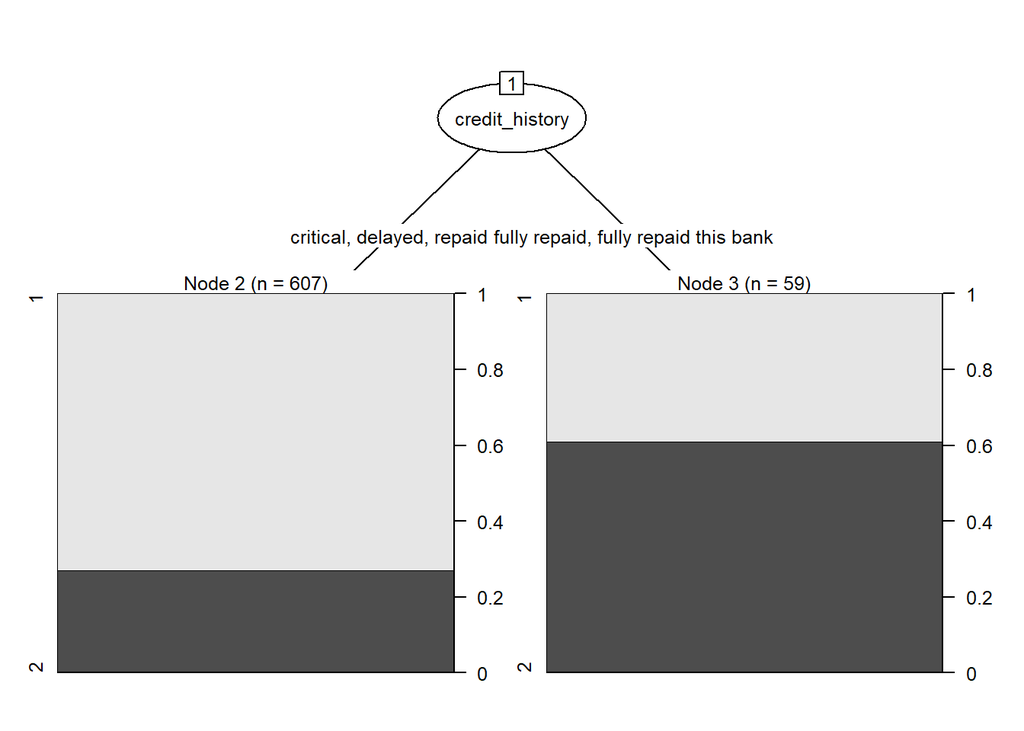

```r
model <- C50::C5.0(trainX, trainy)
plot(model,gp = gpar(fontsize = 9.5))
```

## 4.1 Validació del model amb les dades reservades

Comprovarem la qualitat del model predient la classe default amb les dades de prova que hem inicialitzat anteriorment.

```r
predicted_model <- predict( model, testX, type="class" )
print(sprintf("La precisió de l'arbre és: %.4f%%",100*sum(predicted_model == testy) / length(predicted_model)))
```

```
## [1] "La precisió de l'arbre és: 71.2575%"
```

Ara mostrarem la matriu de confusió. Aquesta permet identificar els tipus d’errors comesos.

```r
mat_conf<-table(testy,Predicted=predicted_model)
mat_conf
```

```
##      Predicted
## testy   1   2
##     1 221  13
##     2  83  17
```

Existeix una altra forma de calcular el percentatge de registres correctament mitjançant la matriu de confusió:

```r
porcentaje_correct<-100 * sum(diag(mat_conf)) / sum(mat_conf)
print(sprintf("El %% de registros correctamente clasificados es: %.4f %%",porcentaje_correct))
```

```
## [1] "El % de registros correctamente clasificados es: 71.2575 %"
```

Efectivament, el percentatge és el mateix que el mostrat anteriorment.

Amb el paquet *gmodels* podem obtenir informació més completa:

```r
if(!require(gmodels)){
    install.packages('gmodels', repos='http://cran.us.r-project.org')
    library(gmodels)
}
```

El mètode CrossTable compara els valors reals amb les dades de les prediccions obtingudes anteriorment.

```r
CrossTable(testy, predicted_model,prop.chisq  = FALSE, prop.c = FALSE, prop.r =FALSE,dnn = c('Reality', 'Prediction'))
```

```
##
##
##    Cell Contents
## |-------------------------|
## |                       N |
## |         N / Table Total |
## |-------------------------|
##
##
## Total Observations in Table:  334
##
##
##              | Prediction
##      Reality |         1 |         2 | Row Total |
## -------------|-----------|-----------|-----------|
##            1 |       221 |        13 |       234 |
##              |     0.662 |     0.039 |           |
## -------------|-----------|-----------|-----------|
##            2 |        83 |        17 |       100 |
##              |     0.249 |     0.051 |           |
## -------------|-----------|-----------|-----------|
## Column Total |       304 |        30 |       334 |
## -------------|-----------|-----------|-----------|
##
##
```

En total tenim 334 observacions i les dues columnes i files corresponents als dos possibles valors de la variable default. Podem veure el total de cadascun dels possibles valors i la diferència amb les dades originals.

La matriu de confusió es divideix en TP (true positive), FP(false positive), FP(false positive) i FN(false negative). En el nostre cas el nombre de casos de cadascun és:

- TP: 221
- FP: 83
- FN: 13
- TN: 17

## 4.2 Prova amb una variació o un altre enfocament algorítmic

Provarem amb alternatives que ens ofereix el paquet C5.0. La tècnica s’anomena *adaptative boosting* i consisteix a generar diversos classificadors, amb els seus corresponents arbres de decisió i la seva sèrie de regles. Cadascun dels classificadors votarà i la classe final serà la que voti la majoria.

```r
model2 <- C50::C5.0(trainX, trainy, trials = 10)
summary(model2)
```

```
##
## Call:
## C5.0.default(x = trainX, y = trainy, trials = 10)
##
##
## C5.0 [Release 2.07 GPL Edition]      Thu Dec 21 22:37:47 2023
## -------------------------------
##
## Class specified by attribute `outcome'
##
## Read 666 cases (4 attributes) from undefined.data
##
## -----  Trial 0:  -----
##
## Decision tree:
##
## credit_history in {critical,delayed,repaid}: 1 (607/164)
## credit_history in {fully repaid,fully repaid this bank}: 2 (59/23)
##
## -----  Trial 1:  -----
##
## Decision tree:
##  1 (666/258.5)
##
## *** boosting reduced to 1 trial since last classifier is very inaccurate
##
## *** boosting abandoned (too few classifiers)
##
##
## Evaluation on training data (666 cases):
##
##      Decision Tree
##    ----------------
##    Size      Errors
##
##       2  187(28.1%)   <<
##
##
##     (a)   (b)    <-classified as
##    ----  ----
##     443    23    (a): class 1
##     164    36    (b): class 2
##
##
##  Attribute usage:
##
##  100.00% credit_history
##
##
## Time: 0.0 secs
```

L’arbre és el mateix que el que s’ha generat anteriorment.

```r
predicted_model2 <- predict( model2, testX, type="class" )
print(sprintf("La precisión del árbol es: %.4f %%",100*sum(predicted_model2 == testy) / length(predicted_model2)))
```

```
## [1] "La precisión del árbol es: 71.2575 %"
```

La precisió del model és la mateixa pel que no millora l’arbre anterior i els resultats són els mateixos.

## 4.3 Interpretació de les variables en les prediccions.

Mitjançant l’enfocament algorítmic Random Forest, obtindrem mètriques d’interpretabilitat per a veure la influència de cadascuna de les variables a les prediccions.

Primer, instal·larem les llibreries **randomForest** i **iml**.

```r
if(!require(randomForest)){
  install.packages('randomForest',repos='http://cran.us.r-project.org')
  library(randomForest)
}
if(!require(iml)){
  install.packages('iml', repos='http://cran.us.r-project.org')
  library(iml)
}
```

Executem randomForest:

```r
train.data <- as.data.frame(cbind(trainX,trainy))
#4 son les variables amb les que treballem
colnames(train.data)[4] <- "default"
rf <-  randomForest(default ~ ., data = train.data, ntree = 50)
```

Generarem una gràfica de la pèrdua de rendiment de les dades. Mesurarem la capacitat del model per classificar correctament

```r
X <- train.data[which(names(train.data) != "default")]
predictor <- Predictor$new(rf, data = X, y = train.data$default)
imp <- FeatureImp$new(predictor, loss = "ce")
```

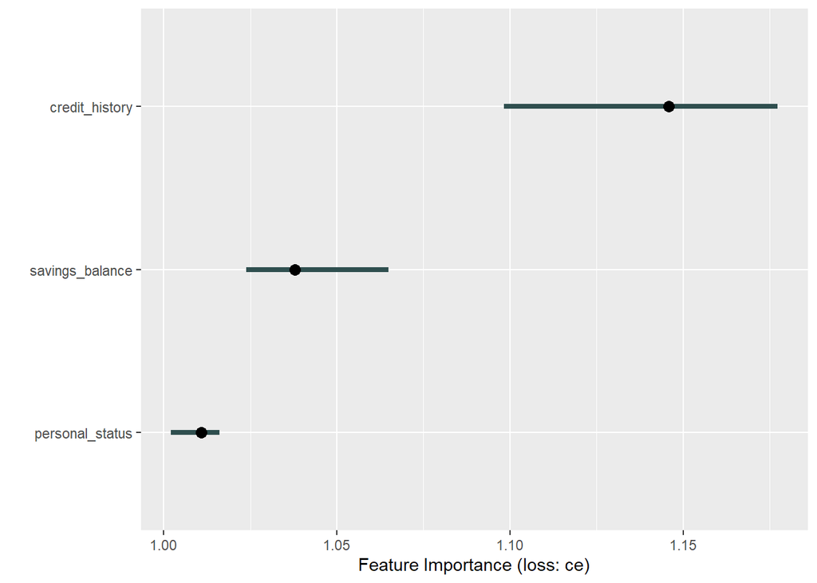

```r
plot(imp)
```

```r
imp$results
```

```
##           feature importance.05 importance importance.95 permutation.error
## 1  credit_history      1.098378   1.145946      1.177297         0.3183183
## 2 savings_balance      1.023784   1.037838      1.064865         0.2882883
## 3 personal_status      1.002162   1.010811      1.016216         0.2807808
```

```r
if(!require(patchwork)){
    install.packages('patchwork',repos='http://cran.us.r-project.org')
    library(patchwork)
}
```

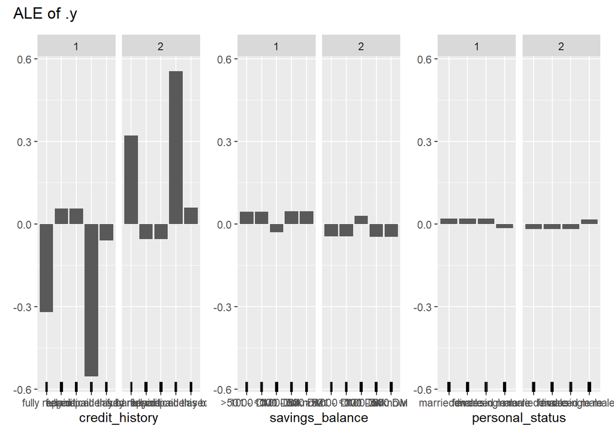

```r
effs <- FeatureEffects$new(predictor)
plot(effs)
```

Com podeu veure als gràfics anteriors i com era d’esperar, la variable credit_history és la que té més importància a les prediccions. De cadascun dels possibles valors, podeu veure com de propensos són a clients de risc o no. Per culpa de la dificultat de lectura del gràfic, no podem extreure més conclusions

## 4.4 Conclusions

Aquest treball ha contribuït a consolidar el coneixement teòric sobre mètodes supervisats, posant-lo en pràctica mitjançant tècniques i mètodes de paquets de R per a la construcció d’arbres de decisió. Aquests arbres es poden utilitzar com a mètodes supervisats per classificar o predir el valor categòric d’una tupla.

Durant la fase d’anàlisi de les dades hem pogut fer diverses observacions. Ens hem trobat que 7 de cada 10 clients havien pagat el seu préstec, la majoria dels préstecs eren per comprar televisions i cotxes i la majoria dels clients eren homes solters.

Un cop fet l’arbre de decisió, l’únic coneixement que podem extreure és que si a l’historial de crèdit s’indica que el client ha reembossat completament el crèdit anterior, té més possibilitats de no pagar l’actual. Hem calculat que la precisió del model és d’un 71,2575%.

Hem obtingut els mateixos resultants i els mateixos arbres de decisió, independentment de la tècnica emprada per a construir-los.